# apply_twocovering_1

## This notebook shows how one could apply SimBAL synthetic spectra generated from two partial covering fraction models

- Using qso continuum generated from simqso and simpaqs
- In this exercise, I will use one of the pregenerated synthetic qso spectra

```python
import numpy as np
import matplotlib.pyplot as plt
from astropy.io import fits
import pickle
```

```python
plt.rcParams['figure.figsize']=(18,5)
plt.rcParams['lines.linewidth']=2
plt.rc('axes',linewidth=3)
plt.rc('xtick',labelsize=18,direction='in',top=True)
plt.rc('ytick',labelsize=18,direction='in',right=True)
plt.rc('xtick.major',size=10,width=3)
plt.rc('ytick.major',size=10,width=3)
plt.rc('legend',framealpha=0.7,fontsize=18,fancybox=True,ec='oldlace')
plt.rc('font',size=20)
plt.rcParams['legend.borderpad']=.3
plt.rcParams['legend.borderaxespad']=.3
plt.rcParams['legend.handlelength']=1.5
```

### Let's get one of the synthetic FeLoBAL spectra

- This set is generated to reproduce the BAL features found in overlapping trough FeLoBAL quasars

```python
fname='results/felobal_ot_pro1_spec.pkl'
file=open(fname,'rb')
temp=pickle.load(file)
OT_Spec=temp[1]
WL=temp[0]
```

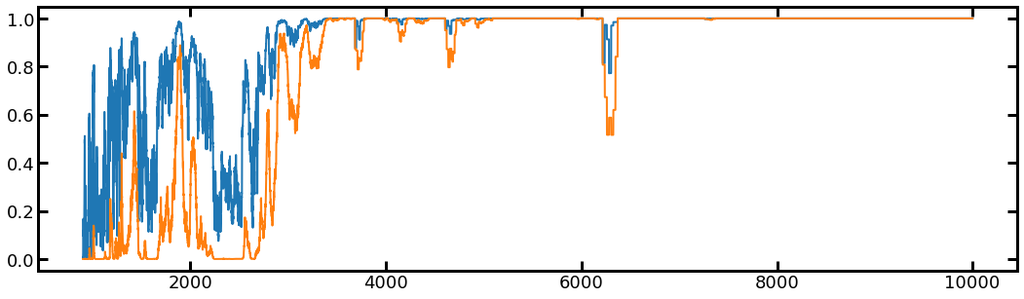

```python
## Pick random II0
idxx1=31
spec1=OT_Spec[idxx1]
plt.clf()
for val in spec1:
    plt.plot(WL,val)
plt.show()
```

### Some models will give just a single normalised spectrum (I/I0), in that case, you can just multiply it to the unabsorbed QSO spectrum to get synthetic FeLoBAL quasar spectrum

### Set of two normalized spectrum:

- I/I0 for emission lines
- I/I0 for power-law continuum

#### Each component, power law emission and line emission, of unabsorbed QSO needs to be multiplied by corresponding normalized spectrum and then added back tohether to obtain the correct synthetic BAL quasar spectrum.

#### simpaqs provide various parameters used to generate unabsorbed qso spectrum with simqso. We will use those numbers to generate (1) power-law continuum model so that we can obtain (2) emission line model by subtracting the qso model by power-law model

## Reading the simpaqs/simqso result

```python
from simqso.sqrun import buildQsoSpectrum
from astropy.cosmology import Planck13
from simqso.sqgrids import *
```

```python
quasar_mod=fits.open('../../simpaqs/simpaqs-main/output/quasar_models/PAQS_quasar_000001.fits')
print(len(quasar_mod))
quasar_par=fits.open('../../simpaqs/simpaqs-main/output/quasar_models/model_parameters.fits')
print(len(quasar_par))
```

```
2
2
```

```python
wave=quasar_mod[1].data['LAMBDA']

M = AbsMagVar(FixedSampler(quasar_par[1].data['absMag']), restWave=1450)
z = RedshiftVar(FixedSampler(quasar_par[1].data['z']))
dust = SMCDustVar(FixedSampler(quasar_par[1].data['smcDustEBV']))

qsos = QsoSimPoints([M, z, dust],cosmo=Planck13,units='luminosity')

contVar = BrokenPowerLawContinuumVar([FixedSampler([quasar_par[1].data['slopes'][0][0]]),
                                      FixedSampler([quasar_par[1].data['slopes'][0][1]])],
                                     [1215.])

# generate lines using the Baldwin Effect emission line model from BOSS DR9
emLineVar = generateBEffEmissionLines(qsos.absMag)

# the default iron template from Vestergaard & Wilkes 2001 was modified to fit BOSS spectra
fescales = [(0,1540,0.5),(1540,1680,2.0),(1680,1868,1.6),(1868,2140,1.0),(2140,3500,1.0)]
feVar = FeTemplateVar(VW01FeTemplateGrid(qsos.z,wave,scales=fescales))

# Now add the features to the QSO grid
qsos.addVars([contVar, emLineVar, feVar])
```

#### Run simqso to obtain power-law continuum model included in qso continuum synthesis

```python
sp,comp = buildQsoSpectrum(wave,qsos.cosmo,qsos.getVars(SpectralFeatureVar),
                           qsos.data[0],save_components=True)
```

```python
em_template=sp.f_lambda-comp['slopes'].f_lambda
```

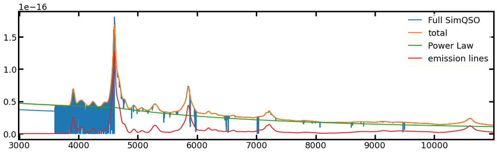

```python
plt.clf()
plt.plot(wave,quasar_mod[1].data['FLUX_DENSITY'],label='Full SimQSO')
plt.plot(sp.wave,sp.f_lambda,label='total')
plt.plot(comp['slopes'].wave,comp['slopes'].f_lambda,label='Power Law')
plt.plot(wave,em_template,label='emission lines')
plt.legend()
plt.xlim([wave[0],wave[-1]])
plt.show()
```

### Now apply the set of I/I0 to the quasar emission lines and power-law continuum separately

```python
def ApplySimBALTwoCovering(z,wl_ii0,ii0s,wl,em,pl):
    ###Let's first redshift the absorption template
    ####First ii0 is for the line emission
    line_ii0=np.interp(wl,wl_ii0*(z+1),ii0s[0])
    ####Second ii0 is for the power law emission
    pl_ii0=np.interp(wl,wl_ii0*(z+1),ii0s[1])
    ###Now apply the two
    return em*line_ii0+pl*pl_ii0
```

```python
model_felobal=ApplySimBALTwoCovering(quasar_par[1].data['z'],WL,spec1,wave,em_template,comp['slopes'].f_lambda)
```

### Here is your final result

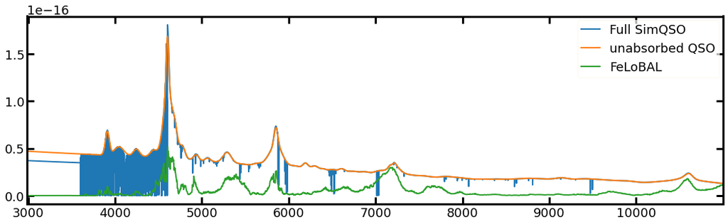

```python
plt.clf()
plt.plot(wave,quasar_mod[1].data['FLUX_DENSITY'],label='Full SimQSO')
plt.plot(sp.wave,sp.f_lambda,label='unabsorbed QSO')
plt.plot(wave,model_felobal,label='FeLoBAL')
plt.legend()
plt.xlim([wave[0],wave[-1]])
plt.show()
```